# Frank et al. (2018): Creating Figure Six for the Manuscript

from “Defining toxicological tipping points in neuronal network development”

Christopher L. Frank, Jasmine P. Brown, Kathleen Wallace, John F. Wambaugh, Imran Shah, and Timothy J. Shafer

Toxicology and Applied Pharmacology 354 (2018) 81-93

https://doi.org/10.1016/j.taap.2018.01.017

## Abstract

Measuring electrical activity of neural networks by microelectrode array (MEA) has recently shown promise for screening level assessments of chemical toxicity on network development and function. Important aspects of interneuronal communication can be quantified from a single MEA recording, including individual firing rates, coordinated bursting, and measures of network synchrony, providing rich datasets to evaluate chemical effects. Further, multiple recordings can be made from the same network, including during the formation of these networks in vitro. The ability to perform multiple recording sessions over the in vitro development of network activity may provide further insight into developmental effects of neurotoxicants. In the current study, a recently described MEA-based screen of 86 compounds in primary rat cortical cultures over 12 days in vitro was revisited to establish a framework that integrates all available primary measures of electrical activity from MEA recordings into a composite metric for deviation from normal activity (total scalar perturbation). Examining scalar perturbations over time and increasing concentration of compound allowed for definition of critical concentrations or “tipping points” at which the neural networks switched from recovery to non-recovery trajectories for 42 compounds. These tipping point concentrations occurred at predominantly lower concentrations than those causing overt cell viability loss or disrupting individual network parameters, suggesting tipping points may be a more sensitive measure of network functional loss. Comparing tipping points for six compounds with plasma concentrations known to cause developmental neurotoxicity in vivo demonstrated strong concordance and suggests there is potential for using tipping points for chemical prioritization.

## Prepare for session

### Load the relevant libraries

```r
knitr::opts_chunk$set(echo = TRUE)
library(gdata)
```

```r
library(httk)
library(ggplot2)
library(scales)
```

### Function to format scientific notation

From https://stackoverflow.com/questions/10762287/how-can-i-format-axis-labels-with-exponents-with-ggplot2-and-scales

```r
scientific_10 <- function(x) {
  out <- gsub("1e", "10^", scientific_format()(x))
  out <- gsub("\\+","",out)
  out <- gsub("10\\^01","10",out)
  out <- parse(text=gsub("10\\^00","1",out))
}
```

### Load the data

```r
Frank2018invivo <- read.csv("Frank2018invivo.csv",stringsAsFactors = F)
chem.table <- Frank2018invivo
```

## Use HTTK to perform IVIVE

### This loops through each study design in the table and runs solve_pbtk:

```r
for (this.row in 1:dim(chem.table))
{
  this.cas <- chem.table[this.row,"Substance_CASRN"]
  if (tolower(chem.table[this.row,"Species"])=="rodent")
  {
    this.species <- "rat"
  } else if (tolower(chem.table[this.row,"Species"])=="rat")
  {
    this.species <- "rat"
  } else if (tolower(chem.table[this.row,"Species"])=="human")
  {
    this.species <- "human"
  }
  else if (tolower(chem.table[this.row,"Species"])=="mouse")
  {
    this.species <- "mouse"
  }
  else browser()
  if (chem.table[this.row,"Route"] %in% c("i.p.","s.c.","i.m.")) iv.dose =T
  else if (chem.table[this.row,"Route"]=="oral") iv.dose = F
  else browser()
  this.dose <- chem.table[this.row,"Dose"]
  this.days <- chem.table[this.row,"Days"]
# Make sure the dose units are in mg/kg body weight:
  if (regexpr("ug",chem.table[this.row,"Dose.Units"])!=-1)
  {
    this.dose <- this.dose/1000
  }
  if (regexpr("/kg",chem.table[this.row,"Dose.Units"])==-1)
  {
    this.dose <- this.dose/0.25
  }
# Here we run the HTTK PBPK Model:
  out <- solve_pbtk(chem.cas=this.cas,
           dose=this.dose,
           species=this.species,
# This was used in 2017 but I don't agree with it anymore:
#           restrictive.clearance=F,
           days=this.days,
           iv.dose=iv.dose,
           default.to.human=T)
# Record the Cmax and the AUC:
  chem.table[this.row,"Cmax"] <- max(out[,"Cplasma"])
  chem.table[this.row,"AUC"] <- max(out[,"AUC"])
}
```

```
## Rat values returned in uM units.
## AUC is area under plasma concentration curve in uM * days units with Rblood2plasma = 3.124859 .
```

```
## Rat values returned in uM units.
## AUC is area under plasma concentration curve in uM * days units with Rblood2plasma = 3.124859 .
```

```
## Rat values returned in uM units.
## AUC is area under plasma concentration curve in uM * days units with Rblood2plasma = 0.73 .
```

```
## Mouse values returned in uM units.
## AUC is area under plasma concentration curve in uM * days units with Rblood2plasma = 0.73 .
```

```
## Rat values returned in uM units.
## AUC is area under plasma concentration curve in uM * days units with Rblood2plasma = 1.04 .
```

```
## Rat values returned in uM units.
## AUC is area under plasma concentration curve in uM * days units with Rblood2plasma = 1.04 .
```

```
## Rat values returned in uM units.
## AUC is area under plasma concentration curve in uM * days units with Rblood2plasma = 1.48 .
```

```
## Rat values returned in uM units.
## AUC is area under plasma concentration curve in uM * days units with Rblood2plasma = 1.48 .
```

```
## Mouse values returned in uM units.
## AUC is area under plasma concentration curve in uM * days units with Rblood2plasma = 1.650213 .
```

```
## Mouse values returned in uM units.
## AUC is area under plasma concentration curve in uM * days units with Rblood2plasma = 1.650213 .
```

```
## Rat values returned in uM units.
## AUC is area under plasma concentration curve in uM * days units with Rblood2plasma = 0.6819349 .
```

```
## Mouse values returned in uM units.
## AUC is area under plasma concentration curve in uM * days units with Rblood2plasma = 0.6798946 .
```

```
## Rat values returned in uM units.
## AUC is area under plasma concentration curve in uM * days units with Rblood2plasma = 0.6768662 .
```

```
## Rat values returned in uM units.
## AUC is area under plasma concentration curve in uM * days units with Rblood2plasma = 0.6768662 .
```

## Make the plot

Comparison between predicted plasma levels for critical concentrations and in vivo estimates from the httk model. For those chemicals with 1) in vitro predicted critical concentrations, 2) in vivo studies indicating neurological effect, and 3) available toxicokinetic data the time-integrated plasma concentration (area under the curve or AUC) was predicted for the LOEL associated with each chemical-specific study. The chemical- specific prediction is indicated by the first four letters of each chemicals name. There were two available studies for each chemical. The identity (âperfect predictorâ) line is indicated by a solid black line, while the dashed lines indicate ten-fold above and below perfect prediction. Because all in vitro treatments were exposed for the same amount of time, the relationship between nominal in vitro concentration and time-integrated concentration is a constant.

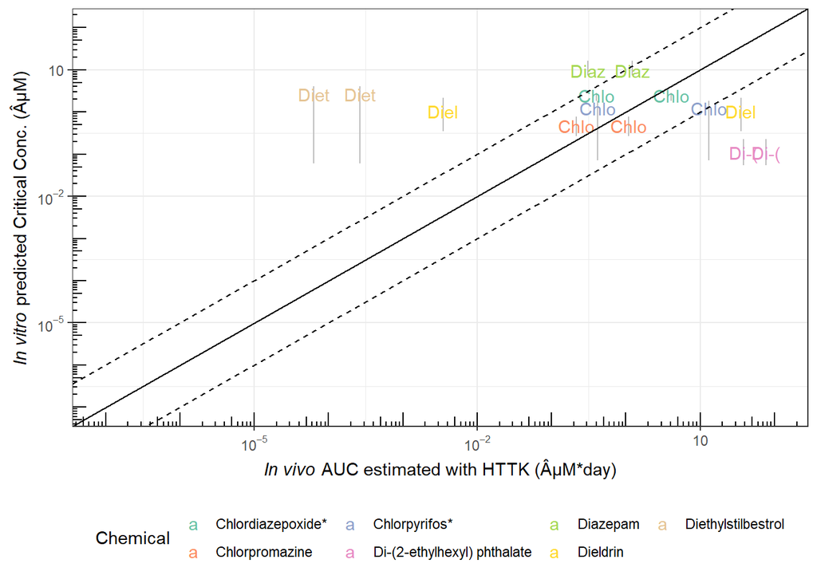

```r
Fig.AUC <- ggplot(data=chem.table) +
  geom_segment(color="grey",aes(x=AUC,y=Lower.95..CI,xend=AUC,yend=Higher.95..CI))+
#  geom_point(aes(x=AUC,y=Critical.concentration,color="Chemical"))+
   geom_text(aes(x=AUC,y=Critical.concentration,label=Compound.abbrev,color=Chemical)) +
   scale_y_log10(label=scientific_10,limits=c(10^-7,100)) +
   scale_x_log10(label=scientific_10,limits=c(10^-7,100)) +
    annotation_logticks() +
    geom_abline(slope=1, intercept=0) +
    geom_abline(slope=1, intercept=1,linetype="dashed") +
    geom_abline(slope=1, intercept=-1,linetype="dashed") +
    xlab(expression(paste(italic("In vivo")," AUC estimated with HTTK (ÂµM*day)"))) +
    ylab(expression(paste(italic("In vitro")," predicted Critical Conc. (ÂµM)"))) +
    scale_color_brewer(palette="Set2") +
    theme_bw()  +
    theme(legend.position="bottom")

print(Fig.AUC)
```